# Manuscript 1 from Fernanda Hansen P. de Moraes Thesis - Cortical folding alterations in humans due to aging and diseases

Fernanda Hansen Pacheco de Moraes

1 dec 2021

Description of the procedures and analysis present in Manuscript 1, **Independent morphological correlates to aging, Mild Cognitive Impairment, and Alzheimer’s Disease**, at the Doctorate Thesis presented to the Programa de Pós-Graduação em Ciências Médicas at the Instituto D’Or de Pesquisa e Ensino as a partial requirement to obtain the Doctorate Degree.

Part of the data used here cannot be shared due to restrictions of the Ethic Committee. Data can be shared upon reasonable request to the corresponding author. To fulfill these limitation, we will generate random data to simulate the results.

Get in touch with us (fernandahmoraes@gmail.com) in case any help is needed, our aim is to improve the code as needed!

```r
setwd("C:/Users/ferna/Documents/GitHub/CorticalFolding_AD_Aging")
```

```r
## define functions

# test angular coeficinet versus theoretical value
test_coef <- function(reg, coefnum, val){
  co <- coef(summary(reg))
  tstat <- (co[coefnum,1] - val)/co[coefnum,2]
  2 * pt(abs(tstat), reg$df.residual, lower.tail = FALSE)
}

# wrap text
wrapper <- function(x, ...) paste(strwrap(x, ...), collapse = "\n")
```

```r
library(readr)
library(tidyverse)
library(lubridate)
library(ggpubr)
library(kableExtra)
library(broom)
library(MASS)
library(cutpointr)
library(ggstatsplot)
library(effects)
library(readxl)
```

```r
# COLOR BLIND PALETTE WITH BLACK
cbbPalette <- c("#000000", "#E69F00", "#56B4E9", "#009E73", "#F0E442", "#0072B2", "#D55E00", "#CC79A7")
cbbPalette2 <- c("#D55E00", "#E69F00", "#56B4E9", "#0072B2", "#CC79A7", "#009E73", "#F0E442")
```

# 1 set seed for random process

```r
set.seed(1)
```

```r
dados_raw <- read_csv("dados_raw.csv")
```

```r
# estimate cortical folding variables
dados_raw <- dados_raw %>%
  mutate(
    # create new variables
    logAvgThickness = log10(AvgThickness),
    logTotalArea = log10(TotalArea),
    logExposedArea = log10(ExposedArea),
    localGI = TotalArea / ExposedArea,
    k = sqrt(AvgThickness) * TotalArea / (ExposedArea ^ 1.25),
    K = 1 / 4 * log10(AvgThickness ^ 2)  + log10(TotalArea) - 5 / 4 * log10(ExposedArea),
    S = 3 / 2 * log10(TotalArea) + 3 / 4 * log10(ExposedArea) - 9 /  4 * log10(AvgThickness ^
                                                                                 2) ,
    I = log10(TotalArea) + log10(ExposedArea) + log10(AvgThickness ^ 2),
    c = as.double(ifelse(
      ROI == "hemisphere", NA, 4 * pi / GaussianCurvature
    )),
    TotalArea_corrected = ifelse(ROI == "hemisphere", TotalArea, TotalArea * c),
    ExposedArea_corrected = ifelse(ROI == "hemisphere", ExposedArea, ExposedArea * c),
    logTotalArea_corrected = log10(TotalArea_corrected),
    logExposedArea_corrected = log10(ExposedArea_corrected),
    localGI_corrected = ifelse(
      ROI == "hemisphere",
      TotalArea / ExposedArea,
      TotalArea_corrected / ExposedArea_corrected
    ),
    k_corrected = ifelse(
      ROI == "hemisphere",
      sqrt(AvgThickness) * log10(TotalArea) / (log10(ExposedArea) ^ 1.25),
      sqrt(AvgThickness) * log10(TotalArea_corrected) / (log10(ExposedArea_corrected ^
                                                                 1.25))
    ),
    K_corrected =  ifelse(
      ROI == "hemisphere",
      1 / 4 * log10(AvgThickness ^ 2) + log10(TotalArea) - 5 / 4 * log10(ExposedArea),
      1 / 4 * log10(AvgThickness ^ 2) + log10(TotalArea_corrected) - 5 / 4 * log10(ExposedArea_corrected)
    ),
    I_corrected = ifelse(
      ROI == "hemisphere",
      log10(TotalArea) + log10(ExposedArea) + log10(AvgThickness ^ 2) ,
      log10(TotalArea_corrected) + log10(ExposedArea_corrected) + log10(AvgThickness ^ 2)
    ),
    S_corrected = ifelse(
      ROI == "hemisphere",
      3 / 2 * log10(TotalArea) + 3 / 4 * log10(ExposedArea) - 9 /  4 * log10(AvgThickness ^ 2) ,
      3 / 2 * log10(TotalArea_corrected) + 3 / 4 * log10(ExposedArea_corrected) - 9 /  4 * log10(AvgThickness ^ 2)
    ),
    Knorm = K_corrected / sqrt(1 + (1 / 4) ^ 2 + (5 / 4) ^ 2),
    Snorm = S_corrected / sqrt((3 / 2) ^ 2 + (3 / 4) ^ 2 + (9 / 4) ^ 2),
    Inorm = I_corrected / sqrt(1 ^ 2 + 1 ^ 2 + 1 ^ 1)
  )

# create age intervals
dados_raw$Age_interval <- cut(dados_raw$Age,
                                       breaks = c(0, 5, 10, 15, 20, 25, 30, 35, 40, 45, 50, 55, 60, 65, 70, 75, 80, 85, 90, 95, 100),
                                       right = FALSE,
                                       include.lowest = TRUE)

dados_raw$Age_interval10 <- cut(dados_raw$Age,
                                         breaks = c(0, 10, 20, 30, 40, 50, 60, 70, 80, 90, 100),
                                         right = FALSE,
                                         include.lowest = TRUE)
```

```r
dados_all <- dados_raw %>% filter(
    Diagnostic == "CONTROLE" |
      Diagnostic == "CCL" |
      Diagnostic == "ALZ", !is.na(logAvgThickness), ExposedArea != 0 | !is.na(localGI), !is.infinite(logExposedArea)) %>%
  droplevels()

dados <- dados_all
```

```r
# rename diagnostics
dados$Diagnostic[dados$Diagnostic == "CONTROLE"] <- "CTL"
dados$Diagnostic[dados$Diagnostic == "ALZ"] <- "AD"
dados$Diagnostic[dados$Diagnostic == "CCL"] <- "MCI"
dados$Diagnostic <- factor(dados$Diagnostic, levels = c("AD", "MCI","CTL"))

# filter data
dados <- dados %>%
  filter(machine == "Philips-Achieva", # include only subjects acquired at Philips Achieva 3T
                          ESC == 8 | ESC > 8, # include only subjects with 8 years of scholarship or more
                          Session == 1) %>% # use only data from Session 1
  droplevels() # delete factor levels
```

Visual QC exclusion:

```r
VisualQC <- read_excel("Verificacao qualidade segmentacao FS Zika e CCD.xlsx",
    sheet = "AD - IDOR ses 1 long", col_types = c("text",
        "text", "skip", "skip", "numeric",
        "skip", "skip", "skip", "skip", "text",
        "text")) %>%
  dplyr::select(-c(session)) %>%
  mutate(Session = 1)

dados <- full_join(dados, VisualQC) %>%
  filter(Classification == 1 | Classification == 2)
```

# 2 Deaging

```r
# define age for deaging
Age.cor = 25

## Avg thickness ----
decay_AvgThickness <-
  filter(
    dados,
    Diagnostic == "CTL",!is.na(TotalArea),!is.nan(TotalArea),!is.infinite(TotalArea)
  ) %>%
  droplevels() %>%
  group_by(ROI) %>%
  do(fit_decay_AvgThickness = tidy(rlm(AvgThickness ~ Age, data = .), conf.int =
                                     TRUE)) %>%
  unnest(cols = c(fit_decay_AvgThickness)) %>%
  filter(term == "Age") %>%
  mutate(c_AvgThickness = estimate,
         std_error_c_AvgThickness = std.error) %>%
  dplyr::select(c(ROI, c_AvgThickness, std_error_c_AvgThickness))

## TotalArea ----
decay_TotalArea <-
  filter(
    dados,
    Diagnostic == "CTL",
    !is.na(TotalArea),
    !is.nan(TotalArea),
    !is.infinite(TotalArea)
  ) %>%
  droplevels() %>%
  group_by(ROI) %>%
  do(fit_decay_TotalArea = tidy(rlm(TotalArea ~ Age, data = .), conf.int =
                                  TRUE)) %>%
  unnest(cols = c(fit_decay_TotalArea)) %>%
  filter(term == "Age") %>%
  mutate(c_TotalArea = estimate,
         std_error_c_TotalArea = std.error) %>%
  dplyr::select(c(ROI, c_TotalArea, std_error_c_TotalArea))

## ExposedArea ----
decay_ExposedArea <-
  filter(
    dados,
    Diagnostic == "CTL",
    !is.na(ExposedArea),
    !is.nan(ExposedArea),
    !is.infinite(ExposedArea)
  ) %>%
  droplevels() %>%
  group_by(ROI) %>%
  do(fit_decay_ExposedArea = tidy(rlm(ExposedArea ~ Age, data = .), conf.int = TRUE)) %>%
  unnest(cols = c(fit_decay_ExposedArea)) %>%
  filter(term == "Age") %>%
  mutate(c_ExposedArea = estimate,
         std_error_c_ExposedArea = std.error) %>%
  dplyr::select(c(ROI, c_ExposedArea, std_error_c_ExposedArea))

## join
dados <- full_join(dados, decay_AvgThickness) %>%
  full_join(decay_TotalArea) %>%
  full_join(decay_ExposedArea) %>%
  mutate(
    AvgThickness_age_decay = AvgThickness - c_AvgThickness * (Age - Age.cor),
    logAvgThickness_age_decay = log10(AvgThickness_age_decay),
    TotalArea_age_decay = TotalArea - c_TotalArea * (Age - Age.cor),
    logTotalArea_age_decay = log10(TotalArea_age_decay),
    ExposedArea_age_decay = ExposedArea - c_ExposedArea * (Age - Age.cor),
    logExposedArea_age_decay = log10(ExposedArea_age_decay),
    K_age_decay = log10(TotalArea_age_decay) + 1/4*log10(AvgThickness_age_decay^2) - 5/4*log10(ExposedArea_age_decay),
    I_age_decay = log10(TotalArea_age_decay) + log10(ExposedArea_age_decay) + log10(AvgThickness_age_decay^2),
    S_age_decay = 3/2*log10(TotalArea_age_decay) + 3/4*log10(ExposedArea_age_decay) - 9/4*log10(AvgThickness_age_decay^2))

dados$logAvgThickness <- as.double(dados$logAvgThickness)
dados$logExposedArea <- as.double(dados$logExposedArea)
dados$logTotalArea   <- as.double(dados$logTotalArea)
```

```r
dados_v1 <- filter(dados, ROI == "F" | ROI == "T" | ROI == "O" | ROI == "P" | ROI == "hemisphere") %>%
  droplevels()

# lobe data
dados_lobos_v1 <- unique(filter(dados, ROI == "F" | ROI == "T" | ROI == "O" | ROI == "P",  !is.na(K_age_decay), SUBJ != "SUBJ211", SUBJ != "SUBJ223")) %>%
  droplevels()

# hemisphere data
dados_hemi_v1 <- unique(filter(dados, ROI == "hemisphere", !is.na(K_age_decay)))
```

```r
dados_hemi_v1 %>%
  group_by(Diagnostic) %>%
  summarise(
    N = n_distinct(SUBJ),
    age = paste(signif(mean(Age), 2), "±", signif(sd(Age), 2)),
    age_range = paste(signif(min(Age), 2), "; ", signif(max(Age), 2)),
    ESC = paste(signif(mean(ESC), 2), "±", signif(sd(ESC), 2))
  )
```

```
## # A tibble: 3 × 5
##   Diagnostic     N age      age_range ESC
##   <fct>      <int> <chr>    <chr>     <chr>
## 1 AD            13 77 ± 6.1 63 ;  86  13 ± 3
## 2 MCI           31 72 ± 4.8 62 ;  82  13 ± 2.4
## 3 CTL           77 66 ± 8.4 43 ;  80  15 ± 2.2
```

# 3 Supplementary Notes: Bimodal distribution of K in Alzheimer’s Disease and optimal cut-off analysis

```r
d <- density(filter(dados_v1, ROI == "hemisphere", Diagnostic == "AD")$K)
valley <- optimize(approxfun(d$x,d$y), interval = c(-0.55,-0.53))$minimum

valley
```

```
## [1] -0.5432187
```

```r
dados_lowAD <- filter(dados_v1, ROI == "hemisphere", Diagnostic == "AD",  K > valley) %>%
  dplyr::select(c(SUBJ, Diagnostic))

dados_highAD <- filter(dados_v1, ROI == "hemisphere", Diagnostic == "AD" ,  K < valley | K == valley ) %>%
  dplyr::select(c(SUBJ, Diagnostic))

dados_highAD_all <- anti_join(dados_v1, dados_lowAD)

dados_lowAD_all <- anti_join(dados_v1, dados_highAD)

dados_v1$ROI <- factor(dados_v1$ROI, levels = c("hemisphere", "F", "O", "P", "T"))

dados_highAD_all$ROI <- factor(dados_highAD_all$ROI, levels = c("hemisphere", "F", "O", "P", "T"))

dados_lowAD_all$ROI <- factor(dados_lowAD_all$ROI, levels = c("hemisphere", "F", "O", "P", "T"))

dados_v1 <- filter(dados_v1, SUBJ != "SUBJ104") %>%
  mutate(ADlevel = "All subjects") %>%
  dplyr::select(c(SUBJ, hemi, Age, Gender, Diagnostic, ESC, ROI, K, K_corrected, S, S_corrected, I, I_corrected, logAvgThickness, ADlevel, `A7/A5`, `TMT B-A`, `DIGIT SPAN BACK`, COGNITIVE_INDEX, `AB1-40`, `AB1-42`, TAU, AB1_ratio, TAU_AB1_42_ratio, TAU_AB1_ratio))

dados_highAD_all <- filter(dados_highAD_all, SUBJ != "SUBJ104") %>%
  mutate(ADlevel = "AD subjects with lower K (K < -0.54)") %>%
  dplyr::select(c(SUBJ, hemi, Age, Gender, Diagnostic, ESC, ROI, K, K_corrected, S, S_corrected, I, I_corrected, logAvgThickness, ADlevel, `A7/A5`, `TMT B-A`, `DIGIT SPAN BACK`, COGNITIVE_INDEX, `AB1-40`, `AB1-42`, TAU, AB1_ratio, TAU_AB1_42_ratio, TAU_AB1_ratio))

dados_lowAD_all <- filter(dados_lowAD_all, SUBJ != "SUBJ104") %>%
  mutate(ADlevel = "AD subjects with higher K (K >= -0.54)") %>%
dplyr::select(c(SUBJ, hemi, Age, Gender, Diagnostic, ESC, ROI, K, K_corrected, S, S_corrected, I, I_corrected, logAvgThickness, ADlevel, `A7/A5`, `TMT B-A`, `DIGIT SPAN BACK`, COGNITIVE_INDEX, `AB1-40`, `AB1-42`, TAU, AB1_ratio, TAU_AB1_42_ratio, TAU_AB1_ratio))

dados_adlevel <- rbind(dados_v1, dados_highAD_all, dados_lowAD_all)

dados_adlevel$ADlevel <- factor(dados_adlevel$ADlevel, levels = c("All subjects", "AD subjects with lower K (K < -0.54)", "AD subjects with higher K (K >= -0.54)"))

fig_K_spread <-  ggplot(dados_adlevel, aes(x = K_corrected, color = Diagnostic, fill = Diagnostic, alpha = 0.4)) +
    geom_density() +
    guides(alpha = "none") +
    theme_pubr() +
    labs(x = "K") +
    facet_grid(ROI ~ ADlevel, scales = "free_y") +
    theme(axis.text.x = element_text(angle = 45, hjust = 1, size=9), axis.title = element_text(size = 11), axis.text = element_text(size = 10), text = element_text(size = 10), strip.background = element_blank(), strip.placement = "outside")+
  scale_fill_manual(values=cbbPalette2) +
  scale_colour_manual(values=cbbPalette2)

ggsave("fig_K_spread.png", plot= fig_K_spread, dpi=1200, width = 17.4, height = 22, units = "cm", device = "png")
```

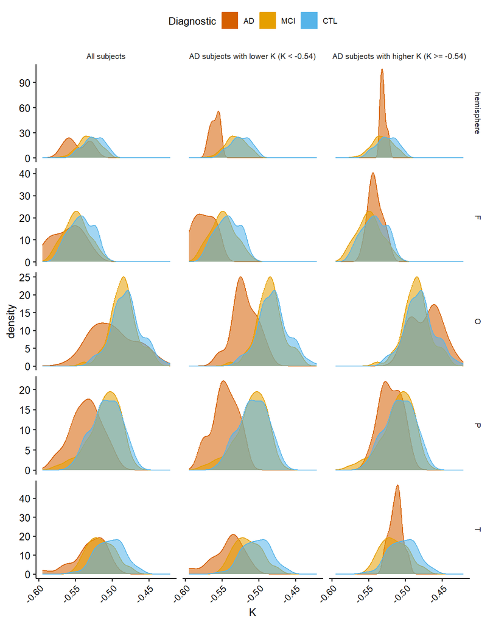

```r
fig_K_spread
```

```r
set.seed(1)

cpK <-
  cutpointr(
    filter(dados_v1, Diagnostic == "AD" |
             Diagnostic == "CTL", ROI == "hemisphere"),
    K,
    Diagnostic,
    pos_class = "AD",
    neg_class = "CTL",
    method = maximize_boot_metric,
    metric = sum_sens_spec,
    na.rm = TRUE,
    boot_runs = 1000,
    use_midpoints = TRUE
  )
summary(cpK)
```

```
## Method: maximize_boot_metric
## Predictor: K
## Outcome: Diagnostic
## Direction: <=
## Nr. of bootstraps: 1000
##
##     AUC   n n_pos n_neg
##  0.8466 178    24   154
##
##  optimal_cutpoint sum_sens_spec    acc sensitivity specificity tp fn fp  tn
##           -0.5421        1.4535 0.8315      0.5833      0.8701 14 10 20 134
##
## Predictor summary:
##     Data       Min.         5%    1st Qu.     Median       Mean    3rd Qu.
##  Overall -0.5705655 -0.5555445 -0.5367181 -0.5277377 -0.5278455 -0.5158408
##       AD -0.5705655 -0.5677069 -0.5606806 -0.5531271 -0.5473437 -0.5313175
##      MCI         NA         NA         NA         NA        NaN         NA
##      CTL -0.5553652 -0.5484493 -0.5346425 -0.5249779 -0.5248068 -0.5145646
##         95%       Max.         SD NAs
##  -0.5032273 -0.4974075 0.01604379   0
##  -0.5257425 -0.5225081 0.01578204   0
##          NA         NA         NA   0
##  -0.5028530 -0.4974075 0.01383501   0
##
## Bootstrap summary:
##           Variable  Min.    5% 1st Qu. Median  Mean 3rd Qu.   95%  Max.   SD
##   optimal_cutpoint -0.55 -0.55   -0.55  -0.54 -0.54   -0.54 -0.53 -0.53 0.01
##              AUC_b  0.71  0.78    0.82   0.85  0.85    0.87  0.91  0.97 0.04
##            AUC_oob  0.51  0.75    0.81   0.85  0.85    0.88  0.94  1.00 0.06
##    sum_sens_spec_b  1.11  1.26    1.39   1.47  1.48    1.58  1.71  1.89 0.14
##  sum_sens_spec_oob  0.79  1.22    1.37   1.44  1.44    1.52  1.66  1.90 0.13
##              acc_b  0.52  0.65    0.74   0.83  0.81    0.88  0.94  0.98 0.09
##            acc_oob  0.46  0.64    0.75   0.82  0.81    0.88  0.92  0.99 0.09
##      sensitivity_b  0.41  0.50    0.57   0.62  0.64    0.70  0.85  1.00 0.11
##    sensitivity_oob  0.00  0.33    0.50   0.60  0.61    0.71  0.92  1.00 0.18
##      specificity_b  0.48  0.64    0.77   0.86  0.84    0.92  0.98  1.00 0.11
##    specificity_oob  0.37  0.61    0.77   0.86  0.84    0.92  0.98  1.00 0.12
##     cohens_kappa_b  0.04  0.15    0.26   0.37  0.41    0.53  0.74  0.91 0.18
##   cohens_kappa_oob -0.10  0.15    0.26   0.35  0.36    0.45  0.61  0.92 0.14
##  NAs
##    0
##    0
##    0
##    0
##    0
##    0
##    0
##    0
##    0
##    0
##    0
##    0
##    0
```

```r
cpk_roc_a <- plot_roc(cpK) +
  theme_pubr()  +
  theme(axis.title = element_text(size = 11),  axis.text = element_text(size = 10), text = element_text(size = 10))

cpK_MCI <-
  cutpointr(
    filter(dados_v1, Diagnostic == "MCI" |
             Diagnostic == "CTL", ROI == "hemisphere"),
    K,
    Diagnostic,
    pos_class = "MCI",
    neg_class = "CTL",
    method = maximize_boot_metric,
    metric = sum_sens_spec,
    na.rm = TRUE,
    boot_runs = 1000,
    use_midpoints = TRUE
  )
summary(cpK_MCI)
```

```
## Method: maximize_boot_metric
## Predictor: K
## Outcome: Diagnostic
## Direction: <=
## Nr. of bootstraps: 1000
##
##     AUC   n n_pos n_neg
##  0.6274 216    62   154
##
##  optimal_cutpoint sum_sens_spec    acc sensitivity specificity tp fn fp tn
##           -0.5258         1.142 0.5463       0.629       0.513 39 23 75 79
##
## Predictor summary:
##     Data       Min.         5%    1st Qu.     Median       Mean    3rd Qu.
##  Overall -0.5680537 -0.5500565 -0.5366192 -0.5269576 -0.5266599 -0.5162116
##       AD         NA         NA         NA         NA        NaN         NA
##      MCI -0.5680537 -0.5529256 -0.5399022 -0.5314849 -0.5312630 -0.5222311
##      CTL -0.5553652 -0.5484493 -0.5346425 -0.5249779 -0.5248068 -0.5145646
##         95%       Max.         SD NAs
##  -0.5045346 -0.4974075 0.01413782   0
##          NA         NA         NA   0
##  -0.5081443 -0.5055914 0.01393539   0
##  -0.5028530 -0.4974075 0.01383501   0
##
## Bootstrap summary:
##           Variable  Min.    5% 1st Qu. Median  Mean 3rd Qu.   95%  Max.   SD
##   optimal_cutpoint -0.54 -0.53   -0.53  -0.53 -0.53   -0.52 -0.52 -0.52 0.00
##              AUC_b  0.50  0.56    0.60   0.63  0.63    0.66  0.69  0.76 0.04
##            AUC_oob  0.46  0.54    0.59   0.63  0.63    0.67  0.72  0.79 0.06
##    sum_sens_spec_b  0.96  1.05    1.14   1.19  1.19    1.24  1.31  1.42 0.08
##  sum_sens_spec_oob  0.80  0.98    1.08   1.16  1.15    1.22  1.31  1.43 0.10
##              acc_b  0.43  0.49    0.54   0.58  0.58    0.63  0.69  0.75 0.06
##            acc_oob  0.38  0.46    0.52   0.57  0.57    0.61  0.68  0.74 0.06
##      sensitivity_b  0.33  0.45    0.54   0.61  0.62    0.70  0.81  0.94 0.11
##    sensitivity_oob  0.17  0.35    0.48   0.61  0.60    0.70  0.83  1.00 0.15
##      specificity_b  0.30  0.40    0.47   0.56  0.57    0.66  0.76  0.84 0.11
##    specificity_oob  0.23  0.36    0.46   0.55  0.56    0.65  0.77  0.89 0.12
##     cohens_kappa_b -0.03  0.04    0.11   0.16  0.16    0.20  0.28  0.42 0.07
##   cohens_kappa_oob -0.18 -0.01    0.07   0.13  0.13    0.18  0.26  0.37 0.08
##  NAs
##    0
##    0
##    0
##    0
##    0
##    0
##    0
##    0
##    0
##    0
##    0
##    0
##    0
```

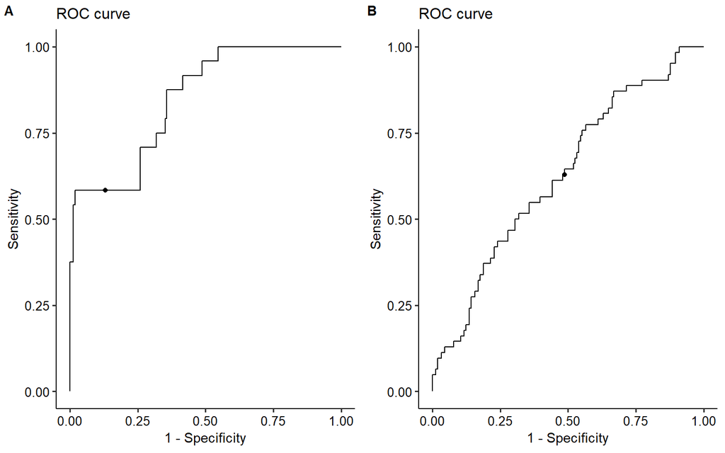

```r
cpk_roc_b <- plot_roc(cpK_MCI) +
  theme_pubr()  +
  theme(axis.title = element_text(size = 11),  axis.text = element_text(size = 10), text = element_text(size = 10))

cpk_roc <- ggarrange(cpk_roc_a, cpk_roc_b, labels = c("A","B"), nrow = 1, ncol = 2, font.label = list(size = 11), common.legend = TRUE, legend = "top")

cpk_roc
```

```r
ggsave("fig_roc.png", plot= cpk_roc, dpi=1200, width = 17.4, height = 11, units = "cm", device = "png")
```

## 3.1 High AD

```r
cpK <-
  cutpointr(
    filter(dados_highAD_all, Diagnostic == "AD" |
             Diagnostic == "CTL", ROI == "hemisphere"),
    K,
    Diagnostic,
    pos_class = "AD",
    neg_class = "CTL",
    method = maximize_boot_metric,
    metric = sum_sens_spec,
    na.rm = TRUE,
    boot_runs = 1000,
    use_midpoints = TRUE
  )
summary(cpK)
```

```
## Method: maximize_boot_metric
## Predictor: K
## Outcome: Diagnostic
## Direction: <=
## Nr. of bootstraps: 998
##
##     AUC   n n_pos n_neg
##  0.9949 168    14   154
##
##  optimal_cutpoint sum_sens_spec    acc sensitivity specificity tp fn fp  tn
##           -0.5517        1.9805 0.9821           1      0.9805 14  0  3 151
##
## Predictor summary:
##     Data       Min.         5%    1st Qu.     Median       Mean    3rd Qu.
##  Overall -0.5705655 -0.5561422 -0.5381372 -0.5269576 -0.5277127 -0.5149849
##       AD -0.5705655 -0.5688961 -0.5642367 -0.5588892 -0.5596777 -0.5541210
##      MCI         NA         NA         NA         NA        NaN         NA
##      CTL -0.5553652 -0.5484493 -0.5346425 -0.5249779 -0.5248068 -0.5145646
##         95%       Max.          SD NAs
##  -0.5031240 -0.4974075 0.016483739   0
##  -0.5524409 -0.5520523 0.006112626   0
##          NA         NA          NA   0
##  -0.5028530 -0.4974075 0.013835011   0
##
## Bootstrap summary:
##           Variable  Min.    5% 1st Qu. Median  Mean 3rd Qu.   95%  Max.   SD
##   optimal_cutpoint -0.56 -0.55   -0.55  -0.55 -0.55   -0.55 -0.55 -0.55 0.00
##              AUC_b  0.98  0.99    0.99   1.00  0.99    1.00  1.00  1.00 0.00
##            AUC_oob  0.96  0.98    0.99   1.00  0.99    1.00  1.00  1.00 0.01
##    sum_sens_spec_b  1.73  1.90    1.97   1.98  1.97    1.99  2.00  2.00 0.03
##  sum_sens_spec_oob  1.29  1.65    1.86   1.97  1.91    1.98  2.00  2.00 0.13
##              acc_b  0.94  0.96    0.98   0.98  0.98    0.99  1.00  1.00 0.01
##            acc_oob  0.90  0.95    0.97   0.98  0.97    0.98  1.00  1.00 0.02
##      sensitivity_b  0.75  0.92    1.00   1.00  0.99    1.00  1.00  1.00 0.03
##    sensitivity_oob  0.29  0.67    0.86   1.00  0.93    1.00  1.00  1.00 0.13
##      specificity_b  0.93  0.96    0.97   0.98  0.98    0.99  1.00  1.00 0.01
##    specificity_oob  0.91  0.95    0.97   0.98  0.98    1.00  1.00  1.00 0.02
##     cohens_kappa_b  0.59  0.77    0.86   0.90  0.90    0.94  1.00  1.00 0.07
##   cohens_kappa_oob  0.00  0.64    0.78   0.85  0.83    0.91  1.00  1.00 0.12
##  NAs
##    0
##    0
##    2
##    0
##    2
##    0
##    0
##    0
##    2
##    0
##    0
##    0
##    0
```

```r
cpk_roc_b <- plot_roc(cpK) +
  theme_pubr()  +
  theme(axis.title = element_text(size = 11),  axis.text = element_text(size = 10), text = element_text(size = 10))

cpk_roc <- ggarrange(cpk_roc_a, cpk_roc_b, labels = c("A","B"), nrow = 1, ncol = 2, font.label = list(size = 11), common.legend = TRUE, legend = "top")
ggsave("fig_roc_highAD.png", plot= cpk_roc, dpi=1200, width = 17.4, height = 11, units = "cm", device = "png")
```

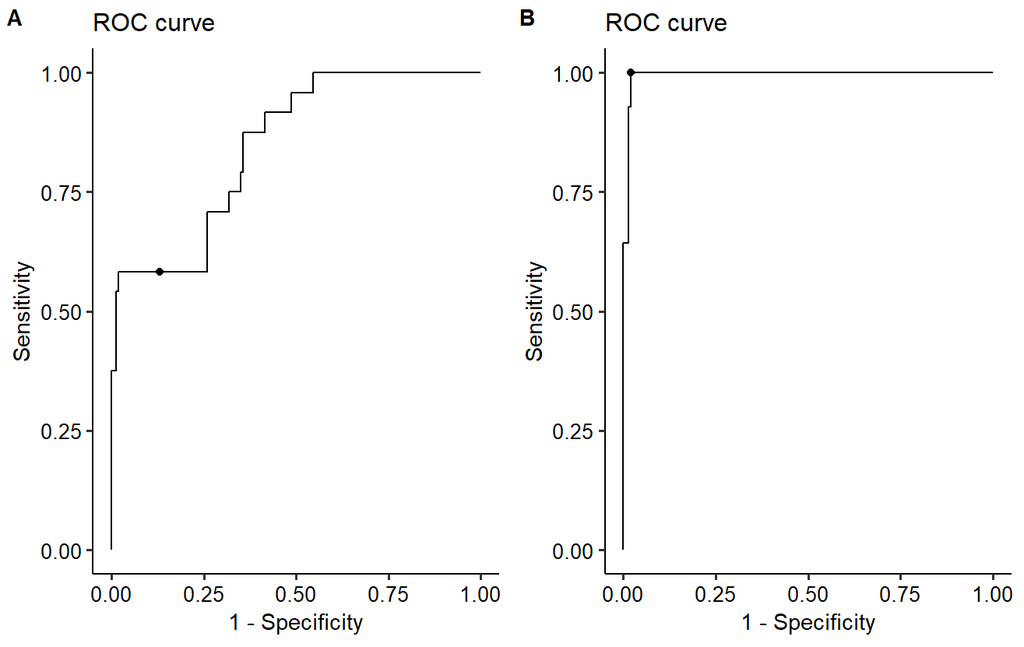

ROC curves derived from the optimal cut-off analysis of K (hemisphere as ROI) to discriminate CTL and AD subjects. (A) All AD subjects included and optimal cut-off=-0.54. (B) AD subjects included if hemispherical K<-0.54, optimal cut-off=-0.55.

```r
cpk_roc
```

```r
filter(dados_adlevel, ROI == "hemisphere") %>%
  group_by(ADlevel, Diagnostic) %>%
  summarise(
    N = n_distinct(SUBJ),
    age = paste(signif(mean(Age), 2), "±", signif(sd(Age), 2)),
    age_range = paste(signif(min(Age), 2), "; ", signif(max(Age), 2))
  )
```

```
## # A tibble: 9 × 5
## # Groups:   ADlevel [3]
##   ADlevel                                Diagnostic     N age      age_range
##   <fct>                                  <fct>      <int> <chr>    <chr>
## 1 All subjects                           AD            12 77 ± 6.3 63 ;  86
## 2 All subjects                           MCI           31 72 ± 4.8 62 ;  82
## 3 All subjects                           CTL           77 66 ± 8.4 43 ;  80
## 4 AD subjects with lower K (K < -0.54)   AD             7 78 ± 7.6 63 ;  86
## 5 AD subjects with lower K (K < -0.54)   MCI           31 72 ± 4.8 62 ;  82
## 6 AD subjects with lower K (K < -0.54)   CTL           77 66 ± 8.4 43 ;  80
## 7 AD subjects with higher K (K >= -0.54) AD             5 76 ± 4.2 71 ;  80
## 8 AD subjects with higher K (K >= -0.54) MCI           31 72 ± 4.8 62 ;  82
## 9 AD subjects with higher K (K >= -0.54) CTL           77 66 ± 8.4 43 ;  80
```

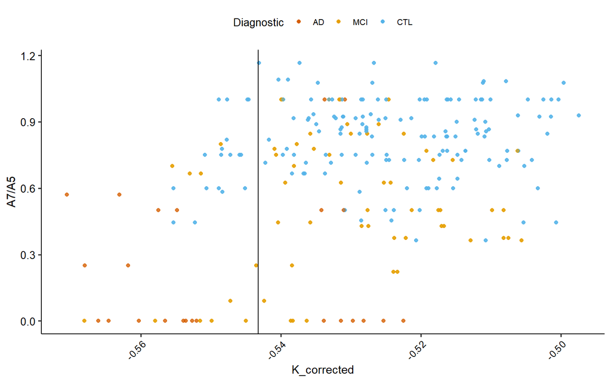

```r
ggplot(filter(dados_adlevel, ROI == "hemisphere"), aes(y = `A7/A5`, x = K_corrected, color = Diagnostic, fill = Diagnostic, alpha = 0.4)) +
    geom_point() +
    geom_vline(xintercept = valley) +
    guides(alpha = "none") +
    theme_pubr() +
    # labs(y = "K") +
    # facet_grid(ROI ~ ., scales = "free_y") +
    theme(axis.text.x = element_text(angle = 45, hjust = 1, size=9), axis.title = element_text(size = 11), axis.text = element_text(size = 10), text = element_text(size = 10), strip.background = element_blank(), strip.placement = "outside")+
  scale_fill_manual(values=cbbPalette2) +
  scale_colour_manual(values=cbbPalette2)
```

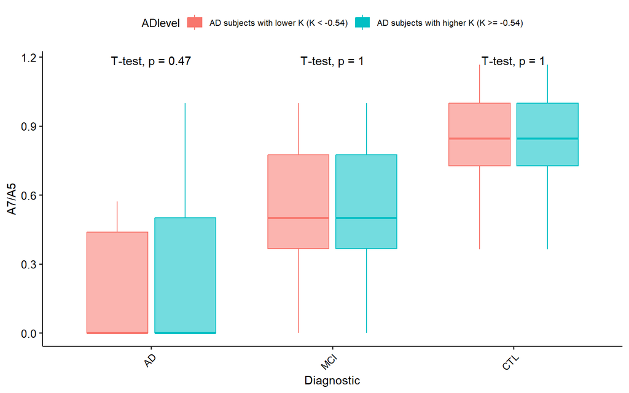

```r
ggplot(filter(dados_adlevel, ROI == "hemisphere", ADlevel != "All subjects"), aes(y = `A7/A5`, x = Diagnostic, color = ADlevel, fill = ADlevel, alpha = 0.4)) +
    geom_boxplot() +
    stat_compare_means(method = "t.test") +
    guides(alpha = "none") +
    theme_pubr() +
    # labs(y = "K") +
    # facet_grid(ROI ~ ., scales = "free_y") +
    theme(axis.text.x = element_text(angle = 45, hjust = 1, size=9), axis.title = element_text(size = 11), axis.text = element_text(size = 10), text = element_text(size = 10), strip.background = element_blank(), strip.placement = "outside")
```

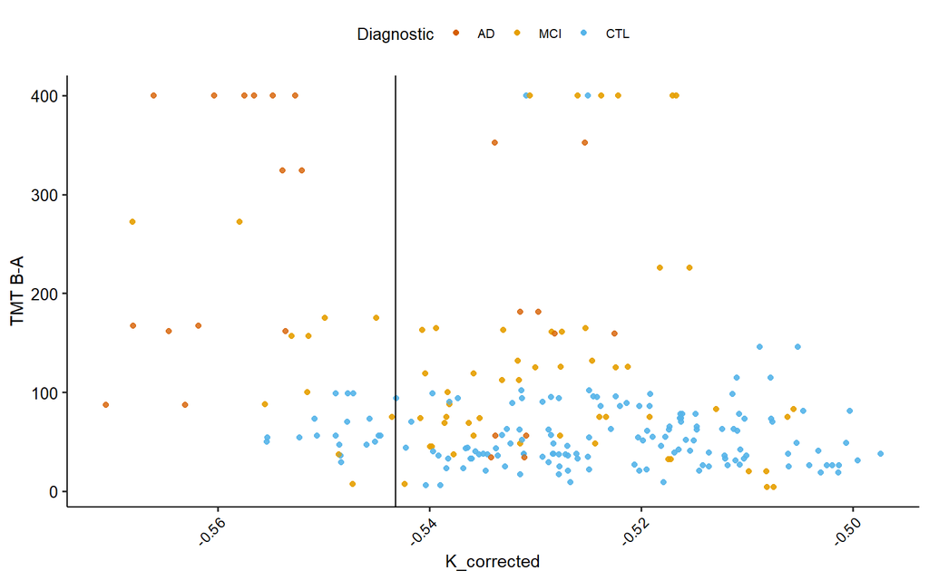

```r
ggplot(filter(dados_adlevel, ROI == "hemisphere"), aes(y = `TMT B-A`, x = K_corrected, color = Diagnostic, fill = Diagnostic, alpha = 0.4)) +
    geom_point() +
    geom_vline(xintercept = valley) +
    guides(alpha = "none") +
    theme_pubr() +
    # labs(y = "K") +
    # facet_grid(ROI ~ ., scales = "free_y") +
    theme(axis.text.x = element_text(angle = 45, hjust = 1, size=9), axis.title = element_text(size = 11), axis.text = element_text(size = 10), text = element_text(size = 10), strip.background = element_blank(), strip.placement = "outside")+
  scale_fill_manual(values=cbbPalette2) +
  scale_colour_manual(values=cbbPalette2)
```

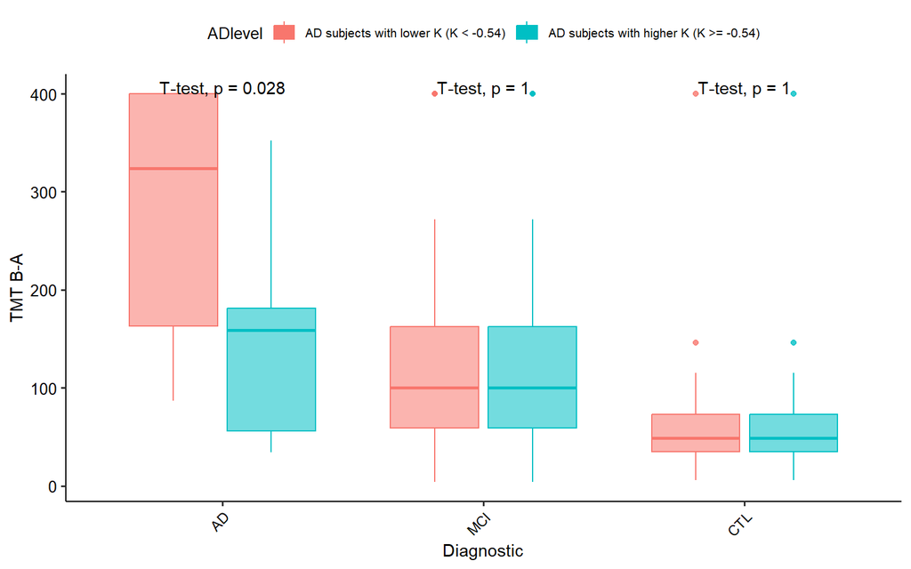

```r
ggplot(filter(dados_adlevel, ROI == "hemisphere", ADlevel != "All subjects"), aes(y = `TMT B-A`, x = Diagnostic, color = ADlevel, fill = ADlevel, alpha = 0.4)) +
    geom_boxplot() +
    stat_compare_means(method = "t.test") +
    guides(alpha = "none") +
    theme_pubr() +
    # labs(y = "K") +
    # facet_grid(ROI ~ ., scales = "free_y") +
    theme(axis.text.x = element_text(angle = 45, hjust = 1, size=9), axis.title = element_text(size = 11), axis.text = element_text(size = 10), text = element_text(size = 10), strip.background = element_blank(), strip.placement = "outside")
```

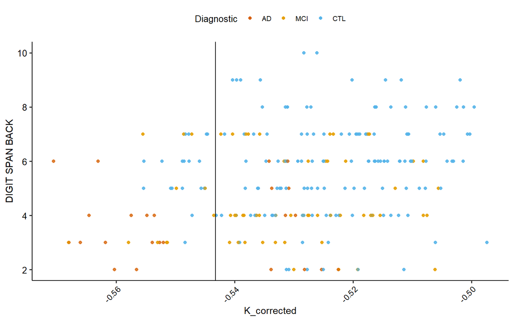

```r
ggplot(filter(dados_adlevel, ROI == "hemisphere"), aes(y = `DIGIT SPAN BACK`, x = K_corrected, color = Diagnostic, fill = Diagnostic, alpha = 0.4)) +
    geom_point() +
    geom_vline(xintercept = valley) +
    guides(alpha = "none") +
    theme_pubr() +
    # labs(y = "K") +
    # facet_grid(ROI ~ ., scales = "free_y") +
    theme(axis.text.x = element_text(angle = 45, hjust = 1, size=9), axis.title = element_text(size = 11), axis.text = element_text(size = 10), text = element_text(size = 10), strip.background = element_blank(), strip.placement = "outside")+
  scale_fill_manual(values=cbbPalette2) +
  scale_colour_manual(values=cbbPalette2)
```

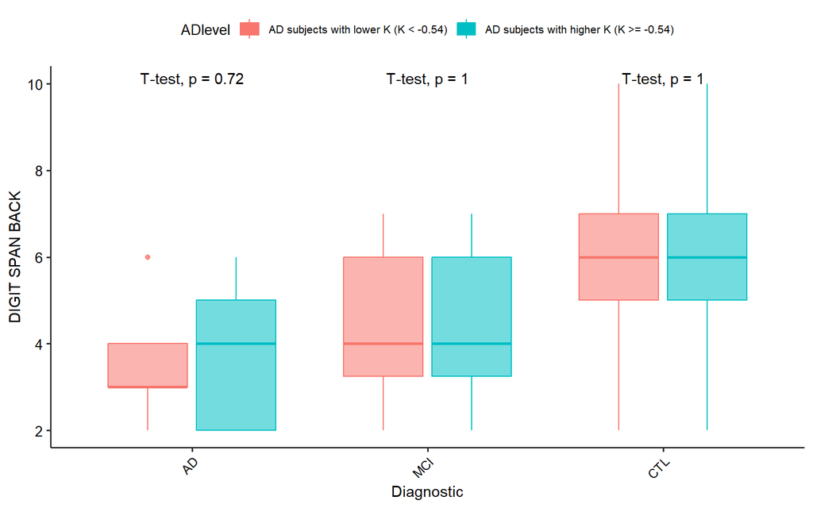

```r
ggplot(filter(dados_adlevel, ROI == "hemisphere", ADlevel != "All subjects"), aes(y = `DIGIT SPAN BACK`, x = Diagnostic, color = ADlevel, fill = ADlevel, alpha = 0.4)) +
    geom_boxplot() +
    stat_compare_means(method = "t.test") +
    guides(alpha = "none") +
    theme_pubr() +
    # labs(y = "K") +
    # facet_grid(ROI ~ ., scales = "free_y") +
    theme(axis.text.x = element_text(angle = 45, hjust = 1, size=9), axis.title = element_text(size = 11), axis.text = element_text(size = 10), text = element_text(size = 10), strip.background = element_blank(), strip.placement = "outside")
```

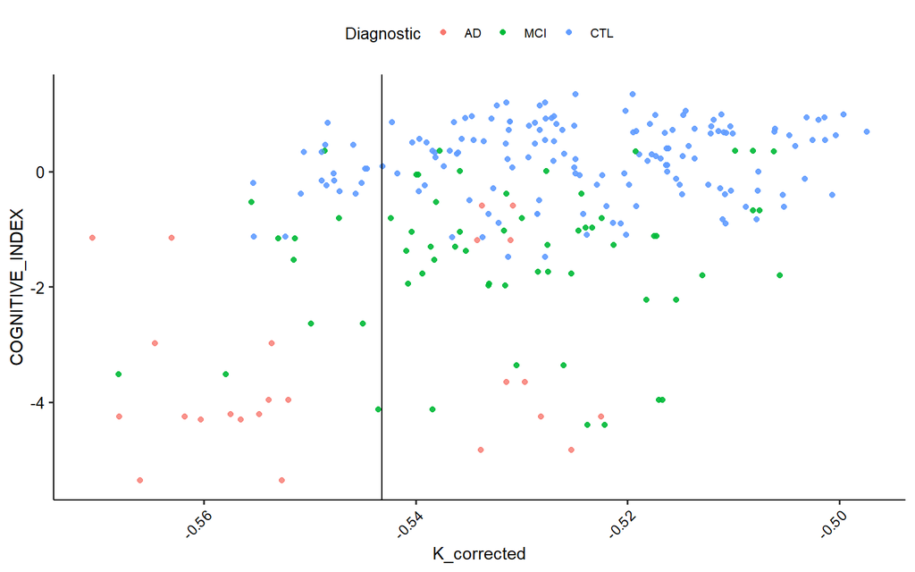

```r
ggplot(filter(dados_adlevel, ROI == "hemisphere"), aes(y = COGNITIVE_INDEX, x = K_corrected, color = Diagnostic, fill = Diagnostic, alpha = 0.4)) +
    geom_point() +
    geom_vline(xintercept = valley) +
    guides(alpha = "none") +
    theme_pubr() +
    # labs(y = "K") +
    # facet_grid(ROI ~ ., scales = "free_y") +
    theme(axis.text.x = element_text(angle = 45, hjust = 1, size=9), axis.title = element_text(size = 11), axis.text = element_text(size = 10), text = element_text(size = 10), strip.background = element_blank(), strip.placement = "outside")
```

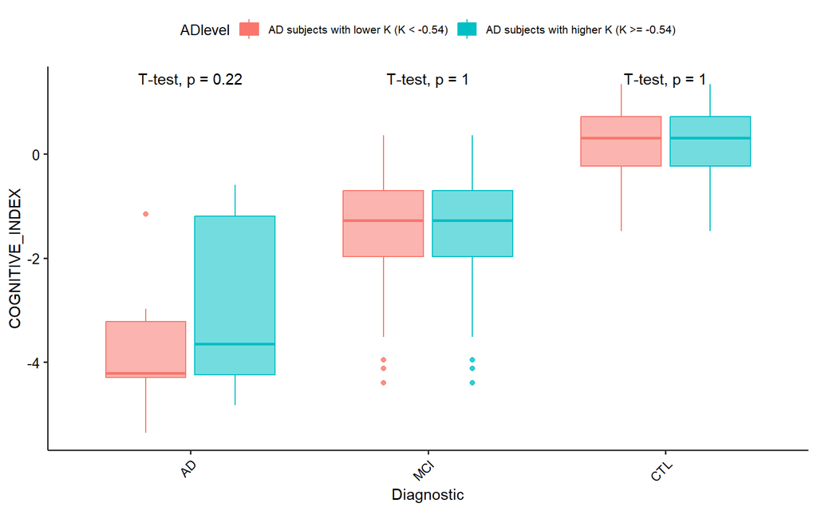

```r
ggplot(filter(dados_adlevel, ROI == "hemisphere", ADlevel != "All subjects"), aes(y = COGNITIVE_INDEX, x = Diagnostic, color = ADlevel, fill = ADlevel, alpha = 0.4)) +
    geom_boxplot() +
    stat_compare_means(method = "t.test") +
    guides(alpha = "none") +
    theme_pubr() +
    # labs(y = "K") +
    # facet_grid(ROI ~ ., scales = "free_y") +
    theme(axis.text.x = element_text(angle = 45, hjust = 1, size=9), axis.title = element_text(size = 11), axis.text = element_text(size = 10), text = element_text(size = 10), strip.background = element_blank(), strip.placement = "outside")
```

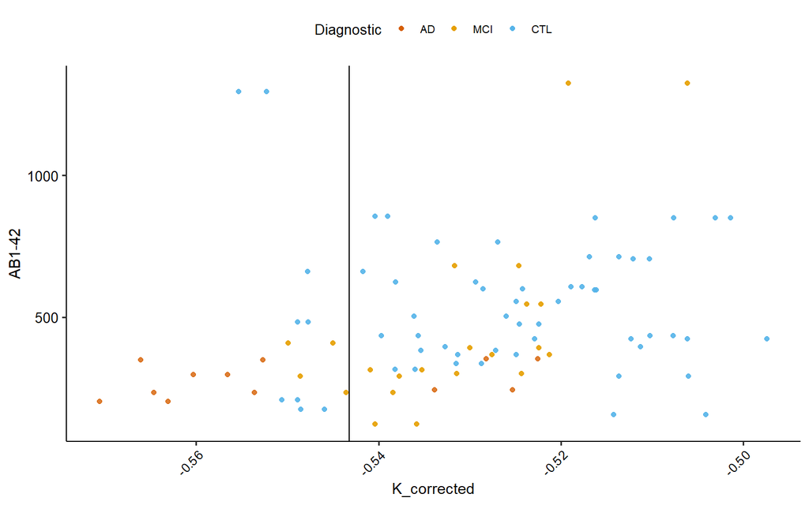

```r
ggplot(filter(dados_adlevel, ROI == "hemisphere"), aes(y = `AB1-42`, x = K_corrected, color = Diagnostic, fill = Diagnostic, alpha = 0.4)) +
    geom_point() +
    geom_vline(xintercept = valley) +
    guides(alpha = "none") +
    theme_pubr() +
    # labs(y = "K") +
    # facet_grid(ROI ~ ., scales = "free_y") +
    theme(axis.text.x = element_text(angle = 45, hjust = 1, size=9), axis.title = element_text(size = 11), axis.text = element_text(size = 10), text = element_text(size = 10), strip.background = element_blank(), strip.placement = "outside")+
  scale_fill_manual(values=cbbPalette2) +
  scale_colour_manual(values=cbbPalette2)
```

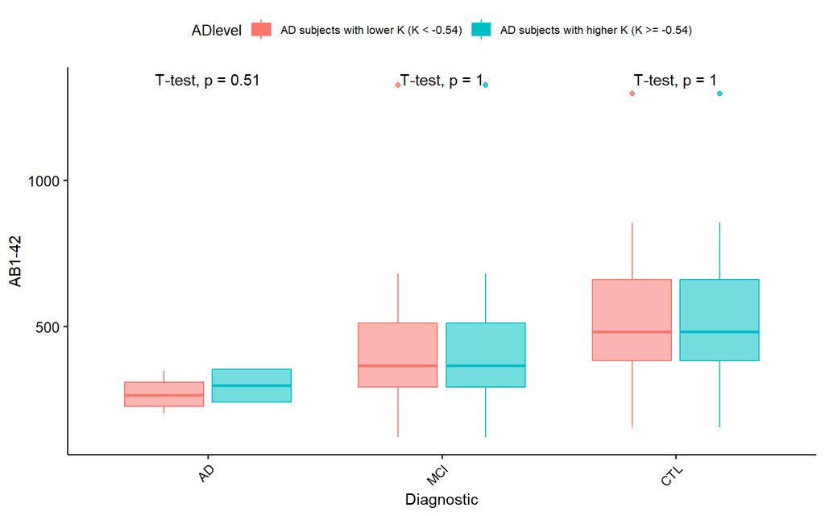

```r
ggplot(filter(dados_adlevel, ROI == "hemisphere", ADlevel != "All subjects"), aes(y = `AB1-42`, x = Diagnostic, color = ADlevel, fill = ADlevel, alpha = 0.4)) +
    geom_boxplot() +
    stat_compare_means(method = "t.test") +
    guides(alpha = "none") +
    theme_pubr() +
    # labs(y = "K") +
    # facet_grid(ROI ~ ., scales = "free_y") +
    theme(axis.text.x = element_text(angle = 45, hjust = 1, size=9), axis.title = element_text(size = 11), axis.text = element_text(size = 10), text = element_text(size = 10), strip.background = element_blank(), strip.placement = "outside")
```

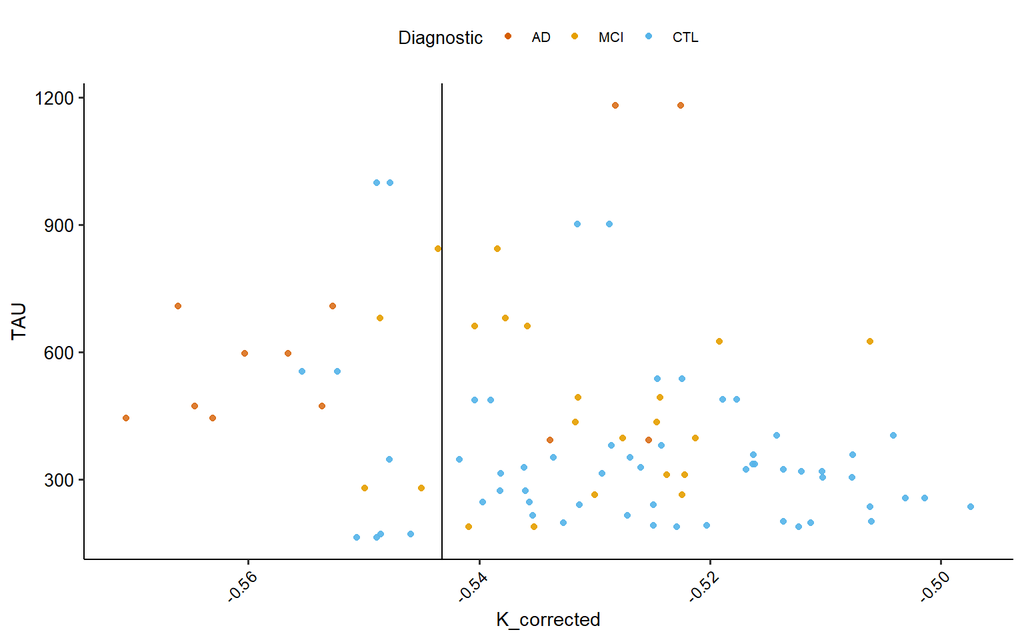

```r
ggplot(filter(dados_adlevel, ROI == "hemisphere"), aes(y = TAU, x = K_corrected, color = Diagnostic, fill = Diagnostic, alpha = 0.4)) +
    geom_point() +
    geom_vline(xintercept = valley) +
    guides(alpha = "none") +
    theme_pubr() +
    # labs(y = "K") +
    # facet_grid(ROI ~ ., scales = "free_y") +
    theme(axis.text.x = element_text(angle = 45, hjust = 1, size=9), axis.title = element_text(size = 11), axis.text = element_text(size = 10), text = element_text(size = 10), strip.background = element_blank(), strip.placement = "outside")+
  scale_fill_manual(values=cbbPalette2) +
  scale_colour_manual(values=cbbPalette2)
```

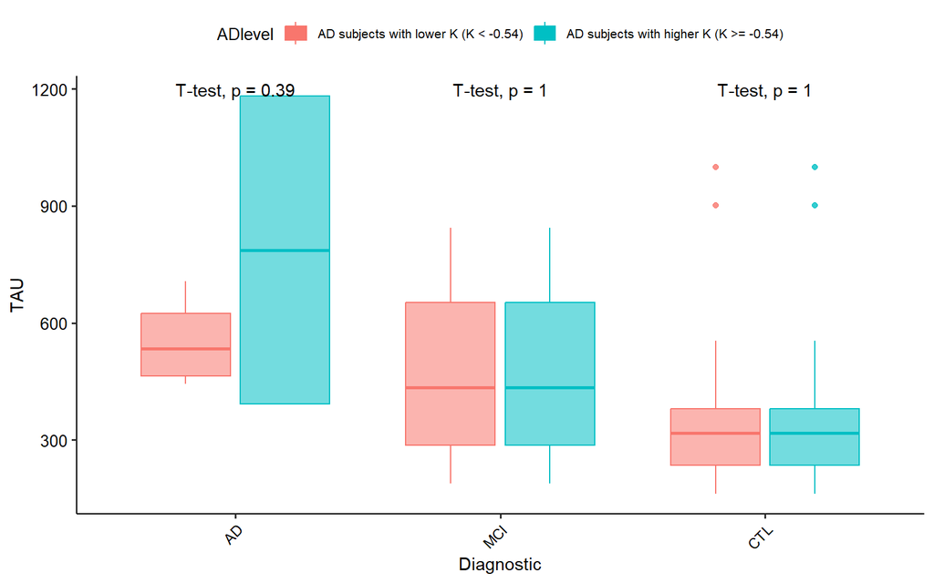

```r
ggplot(filter(dados_adlevel, ROI == "hemisphere", ADlevel != "All subjects"), aes(y = TAU, x = Diagnostic, color = ADlevel, fill = ADlevel, alpha = 0.4)) +
    geom_boxplot() +
    stat_compare_means(method = "t.test") +
    guides(alpha = "none") +
    theme_pubr() +
    # labs(y = "K") +
    # facet_grid(ROI ~ ., scales = "free_y") +
    theme(axis.text.x = element_text(angle = 45, hjust = 1, size=9), axis.title = element_text(size = 11), axis.text = element_text(size = 10), text = element_text(size = 10), strip.background = element_blank(), strip.placement = "outside")
```

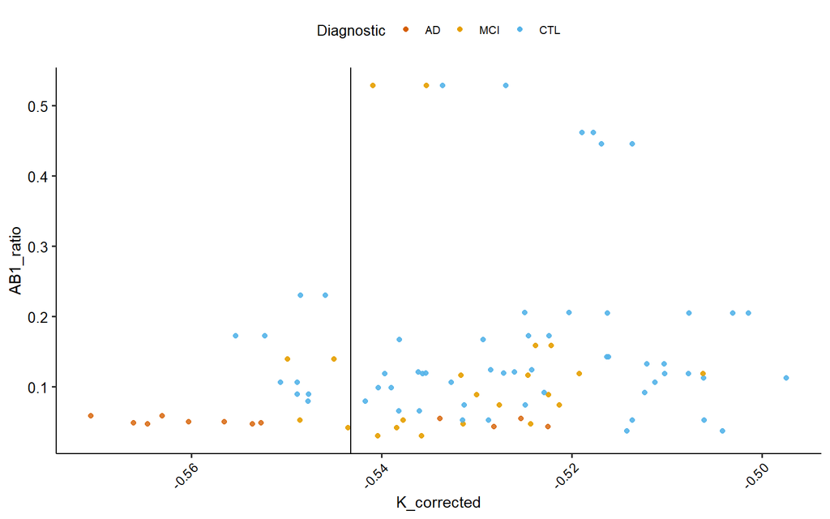

```r
ggplot(filter(dados_adlevel, ROI == "hemisphere"), aes(y = AB1_ratio, x = K_corrected, color = Diagnostic, fill = Diagnostic, alpha = 0.4)) +
    geom_point() +
    geom_vline(xintercept = valley) +
    guides(alpha = "none") +
    theme_pubr() +
    # labs(y = "K") +
    # facet_grid(ROI ~ ., scales = "free_y") +
    theme(axis.text.x = element_text(angle = 45, hjust = 1, size=9), axis.title = element_text(size = 11), axis.text = element_text(size = 10), text = element_text(size = 10), strip.background = element_blank(), strip.placement = "outside")+
  scale_fill_manual(values=cbbPalette2) +
  scale_colour_manual(values=cbbPalette2)
```

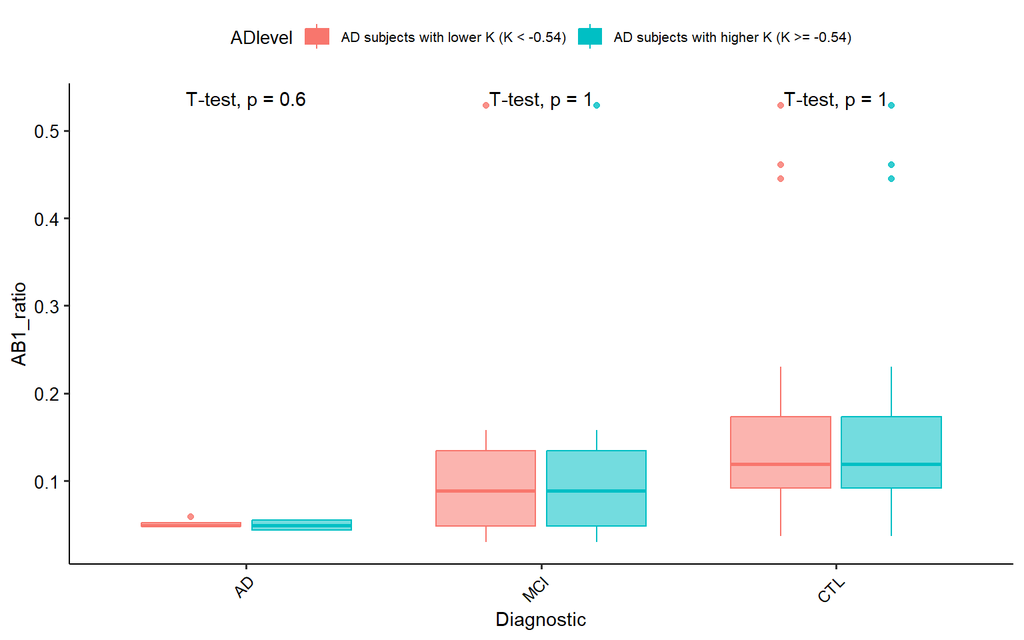

```r
ggplot(filter(dados_adlevel, ROI == "hemisphere", ADlevel != "All subjects"), aes(y = AB1_ratio, x = Diagnostic, color = ADlevel, fill = ADlevel, alpha = 0.4)) +
    geom_boxplot() +
    stat_compare_means(method = "t.test") +
    guides(alpha = "none") +
    theme_pubr() +
    # labs(y = "K") +
    # facet_grid(ROI ~ ., scales = "free_y") +
    theme(axis.text.x = element_text(angle = 45, hjust = 1, size=9), axis.title = element_text(size = 11), axis.text = element_text(size = 10), text = element_text(size = 10), strip.background = element_blank(), strip.placement = "outside")
```

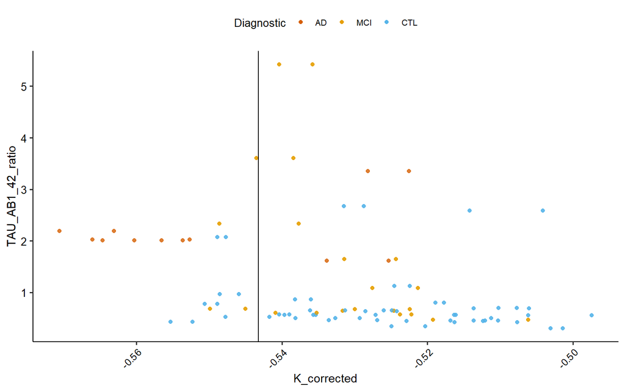

```r
ggplot(filter(dados_adlevel, ROI == "hemisphere"), aes(y = TAU_AB1_42_ratio, x = K_corrected, color = Diagnostic, fill = Diagnostic, alpha = 0.4)) +
    geom_point() +
    geom_vline(xintercept = valley) +
    guides(alpha = "none") +
    theme_pubr() +
    # labs(y = "K") +
    # facet_grid(ROI ~ ., scales = "free_y") +
    theme(axis.text.x = element_text(angle = 45, hjust = 1, size=9), axis.title = element_text(size = 11), axis.text = element_text(size = 10), text = element_text(size = 10), strip.background = element_blank(), strip.placement = "outside")+
  scale_fill_manual(values=cbbPalette2) +
  scale_colour_manual(values=cbbPalette2)
```

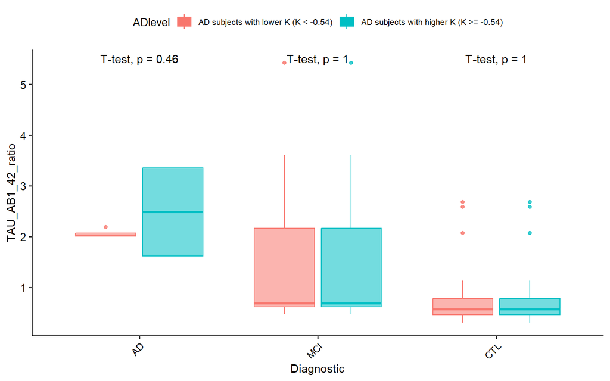

```r
ggplot(filter(dados_adlevel, ROI == "hemisphere", ADlevel != "All subjects"), aes(y = TAU_AB1_42_ratio, x = Diagnostic, color = ADlevel, fill = ADlevel, alpha = 0.4)) +
    geom_boxplot() +
    stat_compare_means(method = "t.test") +
    guides(alpha = "none") +
    theme_pubr() +
    # labs(y = "K") +
    # facet_grid(ROI ~ ., scales = "free_y") +
    theme(axis.text.x = element_text(angle = 45, hjust = 1, size=9), axis.title = element_text(size = 11), axis.text = element_text(size = 10), text = element_text(size = 10), strip.background = element_blank(), strip.placement = "outside")
```

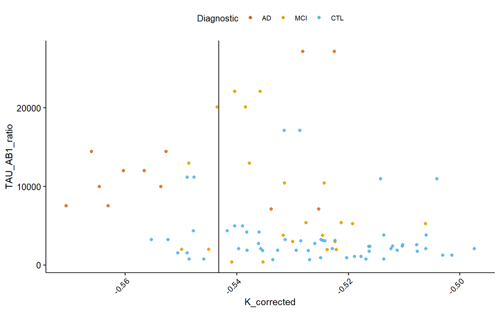

```r
ggplot(filter(dados_adlevel, ROI == "hemisphere"), aes(y = TAU_AB1_ratio, x = K_corrected, color = Diagnostic, fill = Diagnostic, alpha = 0.4)) +
    geom_point() +
    geom_vline(xintercept = valley) +
    guides(alpha = "none") +
    theme_pubr() +
    # labs(y = "K") +
    # facet_grid(ROI ~ ., scales = "free_y") +
    theme(axis.text.x = element_text(angle = 45, hjust = 1, size=9), axis.title = element_text(size = 11), axis.text = element_text(size = 10), text = element_text(size = 10), strip.background = element_blank(), strip.placement = "outside")+
  scale_fill_manual(values=cbbPalette2) +
  scale_colour_manual(values=cbbPalette2)
```

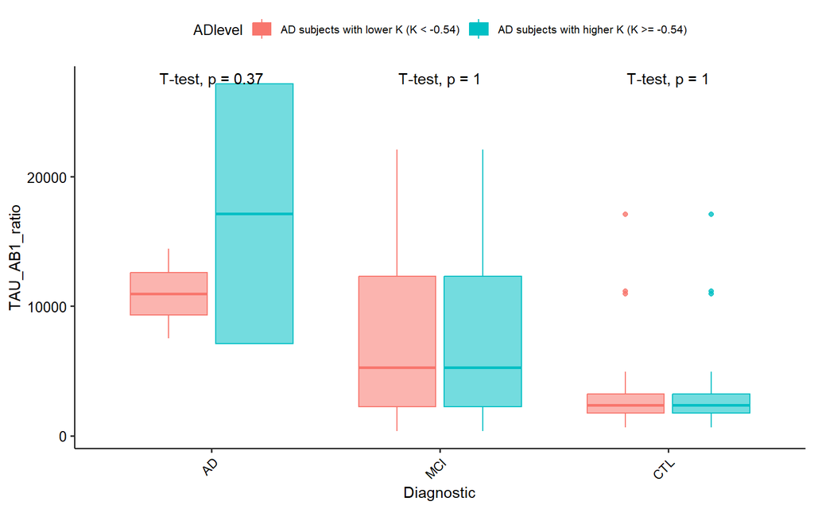

```r
ggplot(filter(dados_adlevel, ROI == "hemisphere", ADlevel != "All subjects"), aes(y = TAU_AB1_ratio, x = Diagnostic, color = ADlevel, fill = ADlevel, alpha = 0.4)) +
    geom_boxplot() +
    stat_compare_means(method = "t.test") +
    guides(alpha = "none") +
    theme_pubr() +
    # labs(y = "K") +
    # facet_grid(ROI ~ ., scales = "free_y") +
    theme(axis.text.x = element_text(angle = 45, hjust = 1, size=9), axis.title = element_text(size = 11), axis.text = element_text(size = 10), text = element_text(size = 10), strip.background = element_blank(), strip.placement = "outside")
```